# Bellabeat Project

Haizhen H.

6/5/2022

## Background

Bellabeat, a high-tech manufacturer of health-focused products for women, believes that analyzing smart devices fitness data could help unlock new growth opportunities for the company. They want the data analytics team to provide a high level recommendations for Bellabeat’s marketing strategy based data insights.

## Business Task

- Analyze smart device usage data in order to gain insight into how consumers use non-Bellabeat smart devices
- Apply those insights into one of the Bellabeat products and make a recommendation

## Stakeholders

*Urška Sršen*: Bellabeat’s co-founder and Chief Creative Officer

*Sando Mur*: Mathematician and Bellabeat’s co-founder; key member of the Bellabeat executive team

## Data Soruce

*FitBit Fitness Tracker Data*: A data set contains personal fitness tracker from thirty fitbit users.It includes information about daily activity, steps, and heart rate that can be used to explore users’ habits

*Source*: [Kaggle](https://www.kaggle.com/datasets/arashnic/fitbit)

*License*: CC0:Public Domain

*Starter Kernels*: * [Julen Aranguren](https://www.kaggle.com/julenaranguren/bellabeat-case-study) * [Anastasiia Chebotina](https://www.kaggle.com/chebotinaa/bellabeat-case-study-with-r)

## Data Preparation

```r
library(tidyverse)
library(lubridate)
setwd('C:/Users/kano/Desktop/Case Study - Bellabeat/Fitabase Data 4.12.16-5.12.16')
files = list.files(pattern='*.csv', full.name=T)
file_names = list.files(pattern='*.csv')

for (i in 1:length(files)){
  assign(file_names[i],read.csv(files[i]))
}
```

```r
df_list = list(dailyActivity_merged.csv,dailyCalories_merged.csv,
               dailyIntensities_merged.csv,dailySteps_merged.csv,
               heartrate_seconds_merged.csv,hourlyCalories_merged.csv,
               hourlyIntensities_merged.csv,hourlySteps_merged.csv,
               minuteCaloriesNarrow_merged.csv,minuteCaloriesWide_merged.csv,
               minuteIntensitiesNarrow_merged.csv,minuteIntensitiesWide_merged.csv,
               minuteMETsNarrow_merged.csv,minuteSleep_merged.csv,
               minuteStepsNarrow_merged.csv,minuteStepsWide_merged.csv,
               sleepDay_merged.csv,weightLogInfo_merged.csv)

sapply(df_list,head)
```

```
## [[1]]
##           Id ActivityDate TotalSteps TotalDistance TrackerDistance
## 1 1503960366    4/12/2016      13162          8.50            8.50
## 2 1503960366    4/13/2016      10735          6.97            6.97
## 3 1503960366    4/14/2016      10460          6.74            6.74
## 4 1503960366    4/15/2016       9762          6.28            6.28
## 5 1503960366    4/16/2016      12669          8.16            8.16
## 6 1503960366    4/17/2016       9705          6.48            6.48
##   LoggedActivitiesDistance VeryActiveDistance ModeratelyActiveDistance
## 1                        0               1.88                     0.55
## 2                        0               1.57                     0.69
## 3                        0               2.44                     0.40
## 4                        0               2.14                     1.26
## 5                        0               2.71                     0.41
## 6                        0               3.19                     0.78
```

[output cut: 370 more lines]

We can noticed some data frames are the combination of other data frames. So I am going to only use the data frame have more information and completeness, and we will focuse on sleeping and weight information:

- sleepDay_merged.csv
- weightLogInfo_merged.csv

## Data cleaning

The data sets I have chosen are small/middle size, so I can perform data cleaning at R studio

Checklist: * Missing Value * Duplicated data * data format * unwanted/irrelevant data

```r
# rename df for further convenience
sleep <- sleepDay_merged.csv
weight <- weightLogInfo_merged.csv

####################################################################
sleep %>%
  is.na() %>%
  sum()             # sum = 0 indicated no missing/NA value
```

```
## [1] 0
```

```r
sleep %>%
  duplicated() %>%
  sum()             # sum = 3 indicated have 3 duplicated rows
```

```
## [1] 3
```

```r
sleep <- sleep %>%
  unique()
nrow(sleep)         # duplicated row has been removed
```

```
## [1] 410
```

```r
str(sleep)
```

```
## 'data.frame':    410 obs. of  5 variables:
##  $ Id                : num  1.5e+09 1.5e+09 1.5e+09 1.5e+09 1.5e+09 ...
##  $ SleepDay          : chr  "4/12/2016 12:00:00 AM" "4/13/2016 12:00:00 AM" "4/15/2016 12:00:00 AM" "4/16/2016 12:00:00 AM" ...
##  $ TotalSleepRecords : int  1 2 1 2 1 1 1 1 1 1 ...
##  $ TotalMinutesAsleep: int  327 384 412 340 700 304 360 325 361 430 ...
##  $ TotalTimeInBed    : int  346 407 442 367 712 320 377 364 384 449 ...
```

```r
sleep <- sleep %>% separate(col= SleepDay,
                            into=c('day','time','stamp'),
                            sep=' ') %>%
                            select(-c(time, stamp))
sleep$day <- as.Date(sleep$day, '%m/%d/%Y')

#################################################################
weight %>%
  is.na() %>%
  sum()                   # 65 missing values from Fat columns
```

```
## [1] 65
```

```r
                          # Invalid information

weight <- weight %>%
  select(-Fat)            #remove Fat columns


weight %>%
  duplicated() %>%
  sum()                   # 0 duplicated
```

```
## [1] 0
```

```r
str(weight)
```

```
## 'data.frame':    67 obs. of  7 variables:
##  $ Id            : num  1.50e+09 1.50e+09 1.93e+09 2.87e+09 2.87e+09 ...
##  $ Date          : chr  "5/2/2016 11:59:59 PM" "5/3/2016 11:59:59 PM" "4/13/2016 1:08:52 AM" "4/21/2016 11:59:59 PM" ...
##  $ WeightKg      : num  52.6 52.6 133.5 56.7 57.3 ...
##  $ WeightPounds  : num  116 116 294 125 126 ...
##  $ BMI           : num  22.6 22.6 47.5 21.5 21.7 ...
##  $ IsManualReport: chr  "True" "True" "False" "True" ...
##  $ LogId         : num  1.46e+12 1.46e+12 1.46e+12 1.46e+12 1.46e+12 ...
```

```r
weight <- weight %>% separate(col= Date,
                            into=c('day','time','stamp'),
                            sep=' ') %>%
                            select(-c(time, stamp))
weight$day <- as.Date(weight$day, '%m/%d/%Y')

####################################################################
```

## Data Analyzing

```r
summary(sleep)
```

```
##        Id                 day             TotalSleepRecords TotalMinutesAsleep
##  Min.   :1.504e+09   Min.   :2016-04-12   Min.   :1.00      Min.   : 58.0
##  1st Qu.:3.977e+09   1st Qu.:2016-04-19   1st Qu.:1.00      1st Qu.:361.0
##  Median :4.703e+09   Median :2016-04-27   Median :1.00      Median :432.5
##  Mean   :4.995e+09   Mean   :2016-04-26   Mean   :1.12      Mean   :419.2
##  3rd Qu.:6.962e+09   3rd Qu.:2016-05-04   3rd Qu.:1.00      3rd Qu.:490.0
##  Max.   :8.792e+09   Max.   :2016-05-12   Max.   :3.00      Max.   :796.0
##  TotalTimeInBed
##  Min.   : 61.0
##  1st Qu.:403.8
##  Median :463.0
##  Mean   :458.5
##  3rd Qu.:526.0
##  Max.   :961.0
```

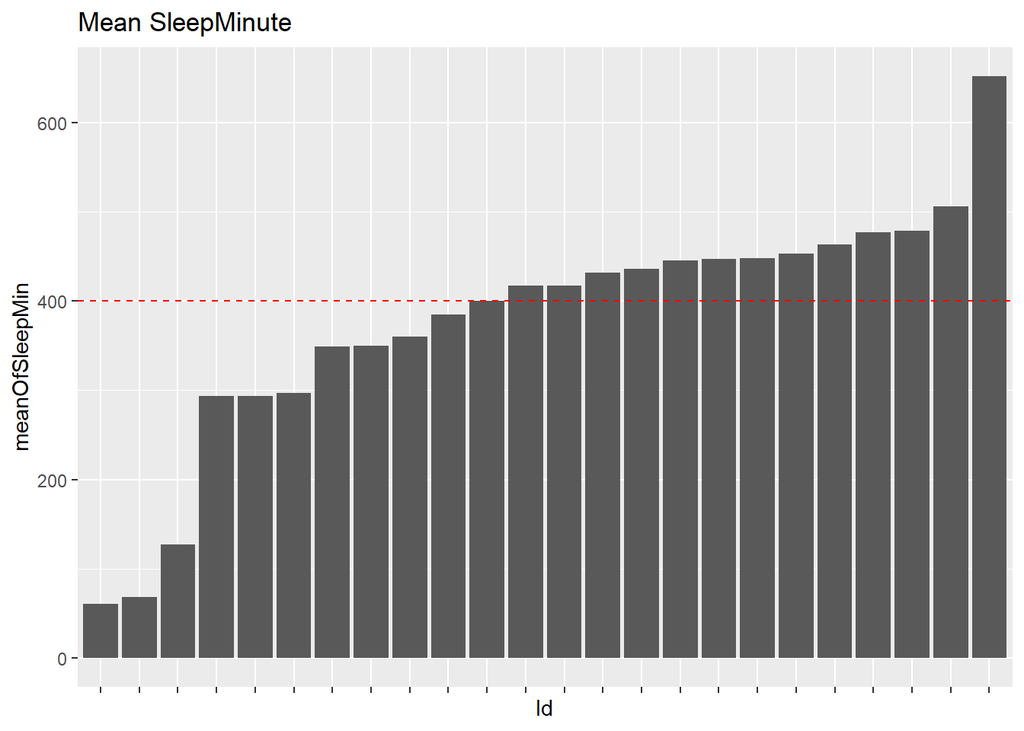

```r
sleep$Id = as.character(sleep$Id)

sleep %>%
  group_by(Id) %>%
  summarize(meanOfSleepMin = mean(TotalMinutesAsleep)) %>%
  ggplot(aes(x=reorder(Id,meanOfSleepMin ), y=meanOfSleepMin)) +
  geom_bar(stat = 'identity') +
  theme(axis.text.x = element_blank()) +
  labs(x='Id',title='Mean SleepMinute ')+
  geom_hline(yintercept = 400, linetype='dashed', color='red')
```

Recommended amount of sleep minutes for adults are 400 or more minutes (red dashed line). We can see there are about half of the respondents cannot meet this recommendation, and three of them have extremely lower sleep minutes that need to be cautious.

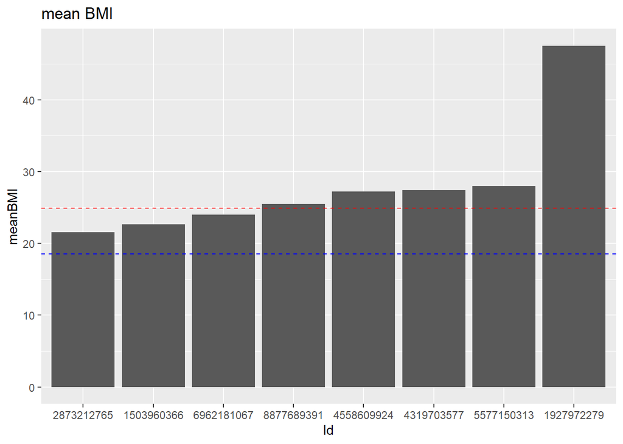

```r
weight$Id = as.character(weight$Id)

weight %>%
  group_by(Id) %>%
  summarise(meanBMI = mean(BMI)) %>%
  ggplot(aes(x=reorder(Id,meanBMI), y=meanBMI)) +
  geom_bar(stat = 'identity') +
  geom_hline(yintercept = 24.9, linetype='dashed', color='red') +
  geom_hline(yintercept = 18.5, linetype='dashed', color='blue') +
  labs(title='mean BMI', x= 'Id')
```

The area between red line and blue line is considered as healthy weight. Above red line is considered as overweight, and below blue line is considered as underweight. Only three people have healthy weight, four people have little bit overweight, and one people have extremely high IBM which can be considered as obesity.

## Recommendation

The data shown they are the common health problems related with sleep and weight which Bellabeat Product should focus on.

Bellabeat Leaf tracker should provide more information about users’ sleep and weight information to help them make healthy decision.